# ETC5550 Project

Thomas Nguyen

21/05/2021

# 1 Discussion of the statistical features of the original data

## 1.1 Overall Feature

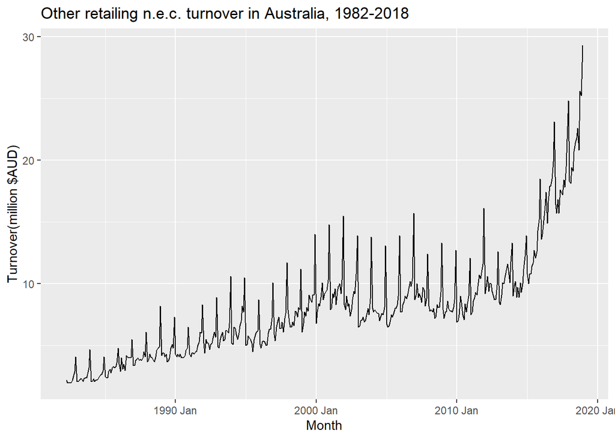

Figure 1.1: Other retailing n.e.c. turnover in Australia, 1982-2018

Figure 1.1 illustrates the turnover of other retailing n.e.c in Australia from 1982-2018. There is a clear upwarding trend and seasonal variation increased proportional to the level of the series. For example, turnover in 2018 is several times higher than that of 1982. The data for Other retailing n.e.c. in Australia has strong seasonality (annual). There is a strong increasing trend in recent years. There is no evidence of any cyclic behaviour here.

## 1.2 Season plot

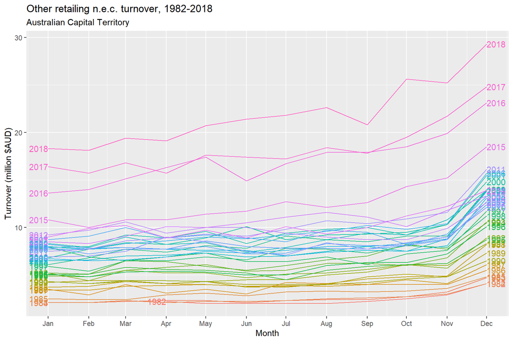

Figure 1.2: Seasonal plot of monthly Other retailing n.e.c. turnover in Australia

Figure 1.2 shows that strong seasonality is evident in the season plot. The turnover of the most recent 3 years are much more higher than that of the rest and there is a drop in September that appeared in recent years. There are small decreases in turnover in February and large jumps in retail turnover in December each year (probably a Christmas effect).

## 1.3 Subseries plot

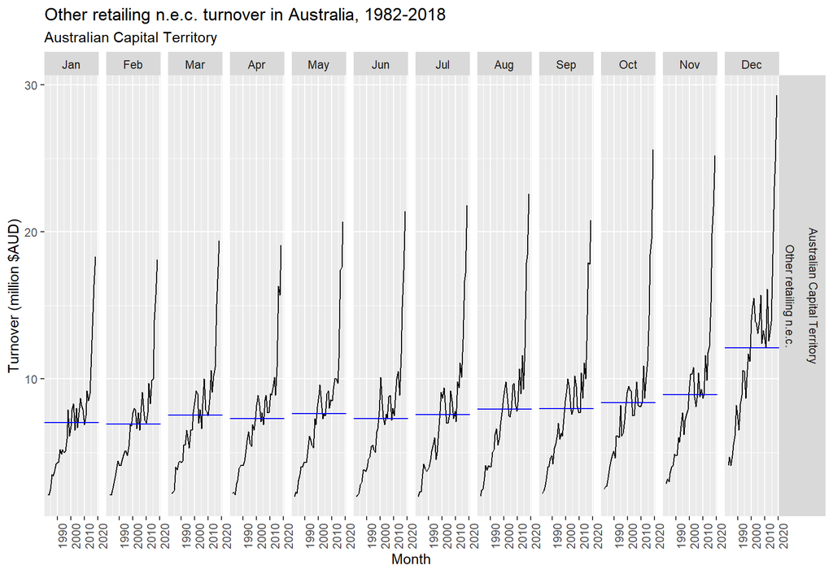

Figure 1.3: Seasonal subseries plot of monthly Other retailing n.e.c. turnover in Australia.

Thw subseries plot 1.3 is “not particularly revealing,” to quote the FPP book. There is a strong, increasing trend in recent years. The largest trend is in December. It is worth notice that while all month follow a massive increasing trend in recent years, October and November achieved the highest growing rate.

## 1.4 STL decomposition

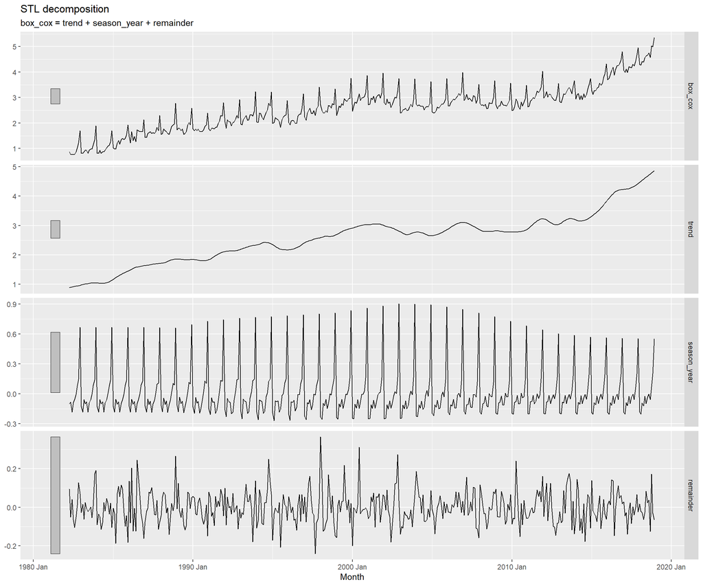

Figure 1.4: Other retailing n.e.c. turnover in Australia, transformed using Box-Cox transformation. The three components obtained from STL decomposition with trend cycle = 19

Figure 1.4 shows an STL decomposition applied to the transformed data from previous part.

The retail Turnover of other retail n.e.c sector has been decomposed into 3 components (trend, seasonality, and remainder) using an STL decomposition. The trend element has been captured well by the decomposition, as it smoothly increases with a similar pattern to the data. The trend is of the same scale as the data (indicated by similarly sized grey bars), and contributes most to the decomposition (having the smallest scale bar). The trend increased steadily for most of the series with occasion dips. However, it grew rapidly in recent years.

The seasonal component changes slowly throughout the series, with the highest seasonal peak locate at the middle of the period (around 2005). The seasonal pattern peak at the last quarter of the year and drop at the start of the year.

The remainder is relatively well-behaved, there is no notable trend in the remainder plot (there is some small leakage of the trend from 2012-2014). I tried several trend window and found that window = 19 is the best, as the trend is not too fragmented and there is no any significant leakage from the trend to the remainder.

# 2 Explanation of transformations and differencing

## 2.1 Explanation of transformations

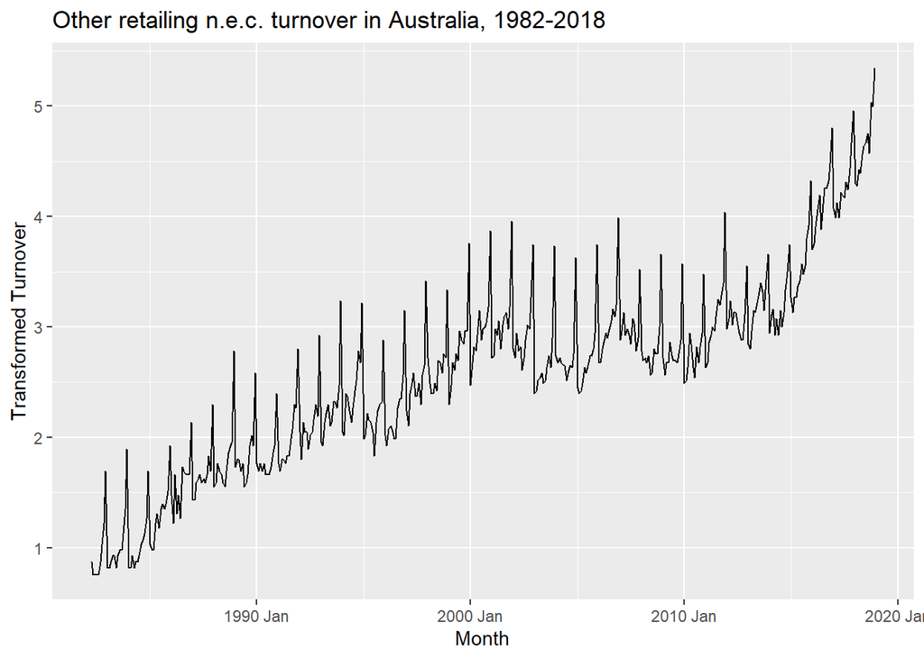

Figure 2.1: Other retailing n.e.c. turnover in Australia, 1982-2018. Box-cox transformed, lambda = 0.254

Figure 1.1 illustrates the turnover of other retailing n.e.c in Australia from 1982-2018. The variation over time is very high. For example, turnover in 2018 is several times higher than that of 1982. Therefore, I applied Box-Cox transformation in order to minimize said variation in the data. I used Guerrero feature to get the suitable value of lambda, which is 0.254. Figure 2.1 shows the transformed data. It can be seen that the variation in data is more stable now.

## 2.2 Explanation of differencing

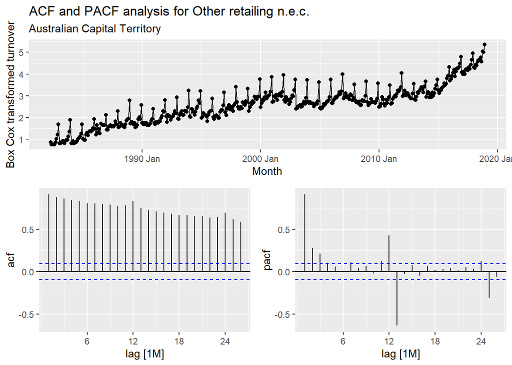

Figure 2.2: ACF and PCF analysis

Figure 2.1 and 2.2 shows that the data is clearly not stationary as ACF does not drop quickly to zero and the value of r1 is high and positive. In both ACF and PACF, there are spikes at 1,12 and 24, indicate seasonality (Annually). Differencing should be applied to the data to obtain a stationary series.

### 2.2.1 Seasonal differencing

Table 2.1: Seasonal Strength of the series

| Seasonal Strength |
| --- |
| 0.89 |

Table 2.2: Unitroot KPSS test

| kpss_stat | kpss_pvalue |
| --- | --- |
| 0.346 | 0.1 |

Table 2.1 shows that the seasonal strength of the series is Fs = 0.89 > 0.64. Therefore one seasonal difference is applied. After that, I used KPSS unitroot test to check if the data is stationary or not. For this test, the null hypothesis is that the data are stationary. The p-value is reported as 0.1, indicate that the null hypothesis is not rejected. We can conclude that the differenced data appear stationary. there is no need for further differencing.

# 3 Short list and methodology

## 3.2 ARIMA models

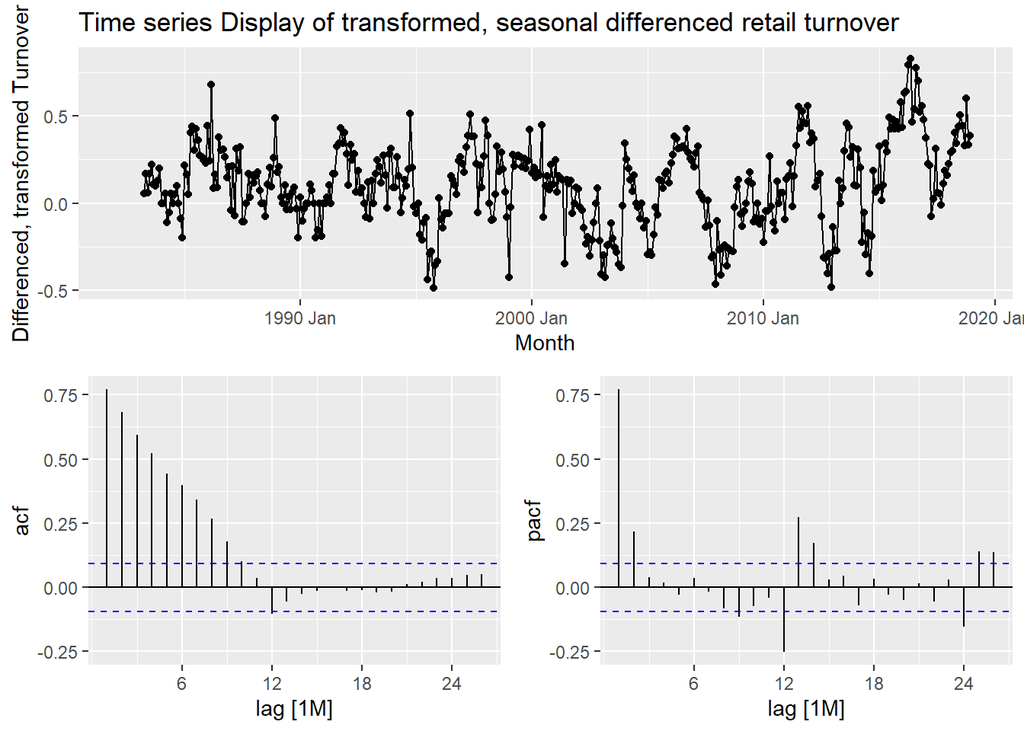

Figure 3.1: ACF and PACF

### 3.2.1 Integrated component

As explained in previous parts, no first difference is applied, therefore d = 0. One seasonal difference is applied, therefore D = 1.

### 3.2.2 Seasonal components

#### 3.2.2.1 Seasonal: AR() component

There are spikes in the PACF at lags 12 and 24. This may suggest a seasonal AR(2) component.

### 3.2.3 Non-seasonal components

#### 3.2.3.1 Non-seasonal: AR() component

PACFs spike at lag 1 and lag 2, then dies out. the ACF is exponentially decaying. These signs suggest a non-seasonal AR(2) component.

#### 3.2.3.3 Conclusion for ARIMA

There are 4 models that made it to the shortlist:  
- ARIMA(2,0,0)(2,1,0)[12]  
- ARIMA(2,0,0)(0,1,1)[12]  
- ARIMA(2,0,1)(2,1,0)[12]  
- ARIMA(2,0,1)(0,1,1)[12]

## 3.3 AIC discussion

Table 3.1: Glance of ETS models

| .model | sigma2 | log_lik | AIC | AICc | BIC |
| --- | --- | --- | --- | --- | --- |
| mam | 0.01 | -1057.83 | 2149.67 | 2151.11 | 2219.18 |
| madm | 0.01 | -1064.48 | 2164.95 | 2166.58 | 2238.56 |
| mnm | 0.01 | -1069.44 | 2168.88 | 2170.01 | 2230.22 |

The AICc is not very different between models. ETS(M,A,M) model has smallest AIC.

Table 3.2: Glance of ARIMA models

| .model | sigma2 | log_lik | AIC | AICc | BIC |
| --- | --- | --- | --- | --- | --- |
| arima200011 | 0.02 | 281.94 | -553.87 | -553.73 | -533.57 |
| arima201011 | 0.02 | 281.94 | -553.87 | -553.73 | -533.57 |
| arima200210 | 0.02 | 265.24 | -518.49 | -518.29 | -494.12 |
| arima201210 | 0.02 | 265.24 | -518.49 | -518.29 | -494.12 |

## 3.4 Test-set accuracy

Table 3.3: RMSE, MAPE and MASE values applied for the last 2 years of data

| .model | .type | RMSE | MAPE | MASE |
| --- | --- | --- | --- | --- |
| madm | Test | 2.39 | 8.18 | 1.86 |
| arima200210 | Test | 2.46 | 8.85 | 2.02 |
| arima201210 | Test | 2.46 | 8.85 | 2.02 |
| mam | Test | 3.54 | 13.79 | 3.06 |
| mnm | Test | 3.58 | 12.97 | 2.93 |
| arima200011 | Test | 3.80 | 13.71 | 3.15 |
| arima201011 | Test | 3.80 | 13.71 | 3.15 |

## 3.5 Conclusion

Based on previous analysis, I would choose ETS(M,A,M) and ARIMA(2,0,0)(2,1,0)[12] for further analysis

# 4 Deep analysis of one ARIMA and one ETS model

## 4.1 Parameter estimates

Table 4.1: ETS model parameter estimates

| term | estimate |
| --- | --- |
| alpha | 0.5144 |
| beta | 0.0001 |
| gamma | 0.0910 |
| l | 2.1978 |
| b | 0.0403 |
| s0 | 0.9650 |
| s1 | 0.8670 |
| s2 | 0.9096 |
| s3 | 1.5632 |
| s4 | 1.0832 |
| s5 | 1.0214 |
| s6 | 0.9675 |
| s7 | 0.9362 |
| s8 | 0.9252 |
| s9 | 0.8774 |
| s10 | 0.9449 |

Table 4.2: ARIMA model parameter estimates

| term | estimate | std.error | statistic | p.value |
| --- | --- | --- | --- | --- |
| ar1 | 0.61 | 0.05 | 13.21 | 0 |
| ar2 | 0.28 | 0.05 | 6.08 | 0 |
| sar1 | -0.52 | 0.05 | -10.79 | 0 |
| sar2 | -0.24 | 0.05 | -4.95 | 0 |
| constant | 0.02 | 0.01 | 3.15 | 0 |

## 4.2 Residual diagnostics

### 4.2.1 Residual diagnostic graphs

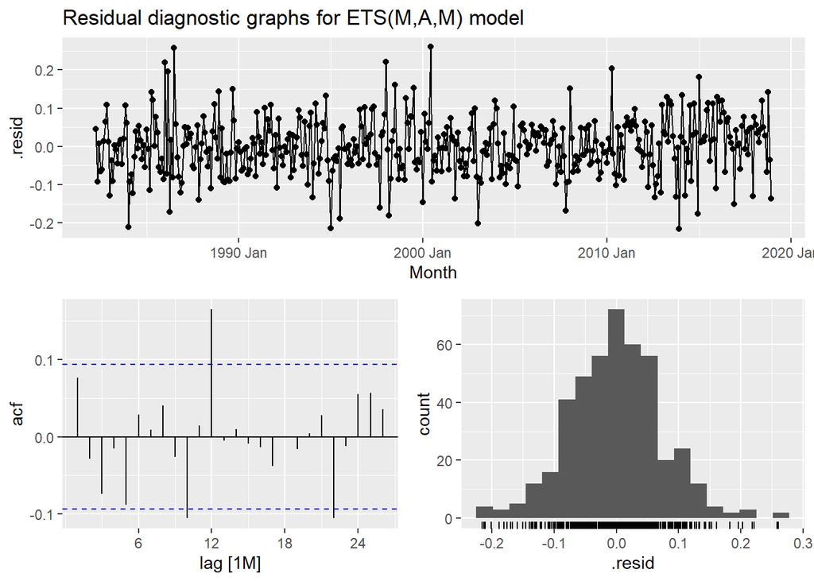

Figure 4.1: Residual diagnostic graphs for ETS(M,A,M) model applied to Other Retailing n.e.c turnover. There are various significant spike in the ACF. Both tail seems a little too long for a normal distribution

Figure 4.1 shows that the ETS model doesn’t seems to account for all available information (i.e residuals is not white noise). The ACF plot shows that there are several significant spikes which means there is information left in the residuals which should be used in computing forecasts. The histogram suggests that the residuals may not be normal since both tails seems a little too long.

I would say that forecasts from this method will probably still be acceptable, but there is information left in the residuals which could be used in computing forecasts. Prediction intervals that are computed assuming a normal distribution may be inaccurate.

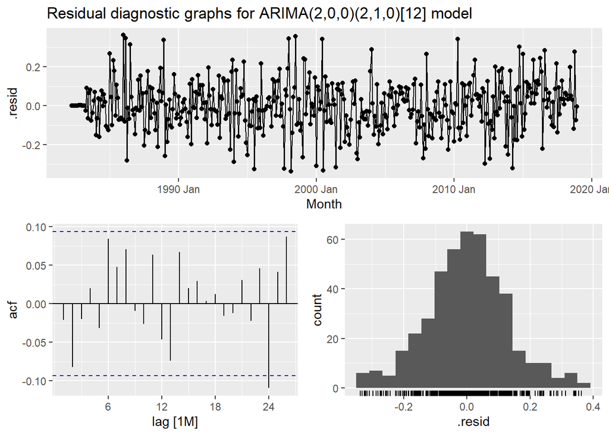

Figure 4.2: Residual diagnostic graphs for ARIMA(2,0,0)(2,1,0)[12] model applied to Other Retailing n.e.c turnover. There is only one significant spike in the ACF. The distribution seems like a normal distribution

Figure 4.2 shows that the ARIMA model does well in capturing all the dynamics in the data as the residuals seem to be white noise. Residuals have mean zero and variation of the residuals is stable throughout the historical data. The ACF plot shows that there is only one significant spike which may happen purely by chance. This means there is no information left in the residuals which should be used in computing forecasts.

I would say that forecasts from this method will probably good as all of the properties is satisfied.

### 4.2.2 Ljung-Box test

To quote Hyndman (2021): “When we look at the ACF plot to see whether each spike is within the required limits, we are implicitly carrying out multiple hypothesis tests, each one with a small probability of giving a false positive. When enough of these tests are done, it is likely that at least one will give a false positive, and so we may conclude that the residuals have some remaining autocorrelation, when in fact they do not.” In order to overcome this problem, I used portmanteau test, in detail the ljung-box test Box et al. (2015). The null hypothesis is: The data are independently distributed, there is no serial correlation.

Table 4.3: Ljung-Box test for ETS(M,A,M) and ARIMA(2,0,0)(2,1,0)[12] model

| Model | LB-Statistics | LB-Pvalue |
| --- | --- | --- |
| mam | 35.88 | 0.00 |
| arima200210 | 26.33 | 0.12 |

The result of Ljung-Box test is shown in table 4.3. For the ETS(M,A,M) model, since p-value < 0.05, we can reject H0 and conclude that the residual from this method is distinguishable from a white noise series. For the ARIMA(2,0,0)(2,1,0)[12] model. Since the p-value = 0.12 > 0.05, we can accept H0 and conclude that the residual from ARIMA(2,0,0)(2,1,0)[12] are indistinguishable from a white noise series.

## 4.3 Forecasts and prediction intervals

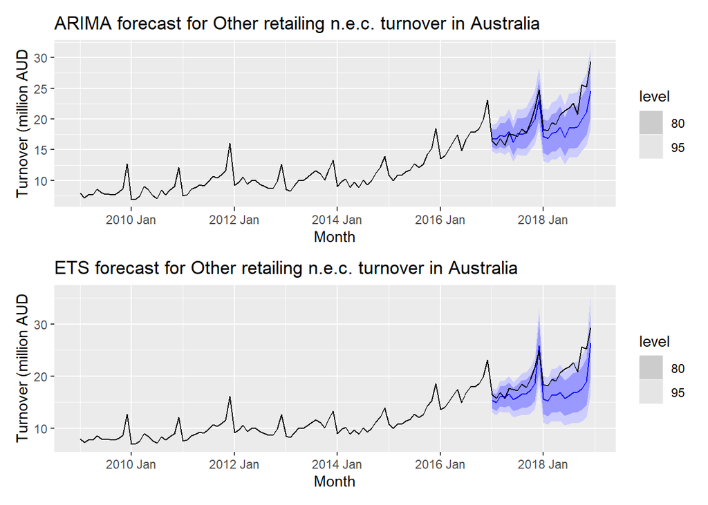

The predictions interval is pretty small. The predictions interval of ETS is much more wider than that of ARIMA. Both model forecast are pretty permisstics, especially for the second year (h =13 to 24)

# 5 Compare ETS and ARIMA models

I think ARIMA gives the better forecast. Based on the residual analysis, the ARIMA model clearly handle the data better and there is less information left in the residuals that can be used to produce forecast (residuals is white noise). In contrast, for the ETS model, there is information left in the residuals. For ETS model, prediction intervals that are computed assuming a normal distribution may be inaccurate as residuals distribution is not normal. From Table 3.3 It is clear that ARIMA(2,0,0)(2,1,0)[12] is slightly more accurate and perform better in point forecast accuracy based on RMSE, MAPE and MASE. Both the CRPS and Winker scores point out that the ARIMA is more accurate on interval forecast.

Table 5.1: Continuous Ranked Probability Score

| .model | percentile | CRPS |
| --- | --- | --- |
| arima | 1.336461 | 1.324638 |
| ets | 2.006931 | 1.987008 |

Table 5.2: Winkle Score

| .model | .type | winkler |
| --- | --- | --- |
| arima | Test | 8.650525 |
| ets | Test | 13.749221 |